# Santa Clara River Plant Phenology

Kristin Art

2023-12-14

```r
knitr::opts_chunk$set(echo = TRUE, message = FALSE, warning = FALSE, results = FALSE)
library(terra)
library(sf)
library(dplyr)
library(tidyr)
library(stringr)
library(ggplot2)
library(here)
library(tmap)
library(cowplot)
library(purrr)

rm(list = ls())
```

### Overview

The purpose of this script is to compare seasonal cycles of plant productivity near the Santa Clara River. We use the normalized difference vegetation index (NDVI) as a proxy for plant productivity. The NDVI is calculated as:

$$NDVI = \frac{NIR - Red}{NIR +
Red}$$
where:

- NIR is the amount of near-infrared reflectance
- Red is the amount of red reflectance

Leaf pigments (chlorophyll-*a*, chlorophyll-*b*, $\beta$-carotene, etc.) are the dominant factor that controls the amount of reflectance of red visible light while scattering in the spongey mesophyll is the dominant factor that controls the amount of reflectance of near-infrared light. The moisture content of leaves is the dominant factor that controls the amount of reflectance of middle-infrared light, but is not considered in the NDVI.

In this exercise, we compute monthly NDVI values between June 2018 and July 2019 from Landsat satellite images. We compare the NDVI values across 5 study sites near the Santa Clara River that represent the following types of vegetation:

- riparian forest
- grasslands
- chaparral shrublands

We do so to understand the phenological cycles of plant communities near the Santa Clara River.

### Background

The Santa Clara River watershed is located in southern California and is characterized by a Mediterranean climate; summers are warm/ hot and dry while winters are mild and wet. Higher elevation areas tend to experience slightly cooler temperatures and occasional heatwaves occur in the summers. The Santa Clara River watershed experiences a pronounced wet-dry seasonal pattern, with most of the annual precipitation occurs during the winter months (November to March); this leaves the area prone to periodic drought and wildfire during the dry summers.

Native vegetation in the area includes chaparral, coastal sage scrub, oak woodlands, cottonwood trees, and willow trees. Each of these vegetation types have adapted the timing of their life cycle events, or phenology, to survive and reproduce in the local climate of the Santa Clara River watershed. For vegetation, key phenological events include growing leaves, flowering, senescing (leaves dying), and more. Plant species in the area can utilize one of the following phenological strategies:

- evergreen: maintain leaves year-round
- winter deciduous: lose leaves in the winter and grow new leaves in the spring
- drought deciduous: lose leaves in the summer when water is limited

Local animal species often adapt their own phenology to take advantage of the vegetation cycles. The timing of such events for both plants and animals is being altered as the climate shifts, which is why studying both plant and animal phenology can provide valuable insight into the health of an ecosystem.

### Methods

#### Data

*Satellite Imagery*

We utilized 8 pre-processed scenes of reflectance that were captured by the OLI sensor of the Landsat Operational Land Imager. The scenes include Level 2 surface reflectance products that contain bands 2-7. The scale factor was pre-set to 100 and erroneous values were set to NA. Each file includes the date the scene was taken as part of the filename.

*Study sites*

We utilized shapefile that depict 5 specific sites in the Santa Clara River watershed that were collected by Dr. Christopher Kibler from the University of California, Santa Barbara. The shapefile contains polygons that represent sites that are dominantly composed of one of the following vegetation types: chaparral shrubland, grassland, and riparian forest.

#### Approach

We began our analysis by converting reflectance data from 8 Landsat scenes into NDVI, a measure of vegetation productivity.

```r
# define function to calculate NDVI
calculate_ndvi <- function(nir, red) {
  ndvi <- (nir - red) / (nir + red)
}

# load and process ndvi data
files <- list.files(here::here("data"), pattern = "*.tif", full.names = TRUE)

# define function to load data and create ndvi layer
create_ndvi_layer <- function(i) {
  file <- files[i]
  landsat <- terra::rast(file)
  names(landsat) <- c("blue", "green", "red", "NIR", "SWIR1", "SWIR2")
  ndvi <- terra::lapp(landsat[[c(4, 3)]], fun = calculate_ndvi)
  return(ndvi)
}

# test function on 1 fie
test <- create_ndvi_layer(1)
test

# apply function to all files and stack layers
all_ndvi <- c(
  create_ndvi_layer(1),
  create_ndvi_layer(2),
  create_ndvi_layer(3),
  create_ndvi_layer(4),
  create_ndvi_layer(5),
  create_ndvi_layer(6),
  create_ndvi_layer(7),
  create_ndvi_layer(8)
)

# update layer names to match dates
names(all_ndvi) <- c(
  "2018-06-12",
  "2018-08-15",
  "2018-10-18",
  "2018-11-03",
  "2019-01-22",
  "2019-02-23",
  "2019-04-12",
  "2019-07-01"
)

all_ndvi
```

Next, we calculated the NDVI at each of the 5 study sites for each monthly scene. The monthly values were calculated by finding the mean NDVI value of all raster cells included in each study site.

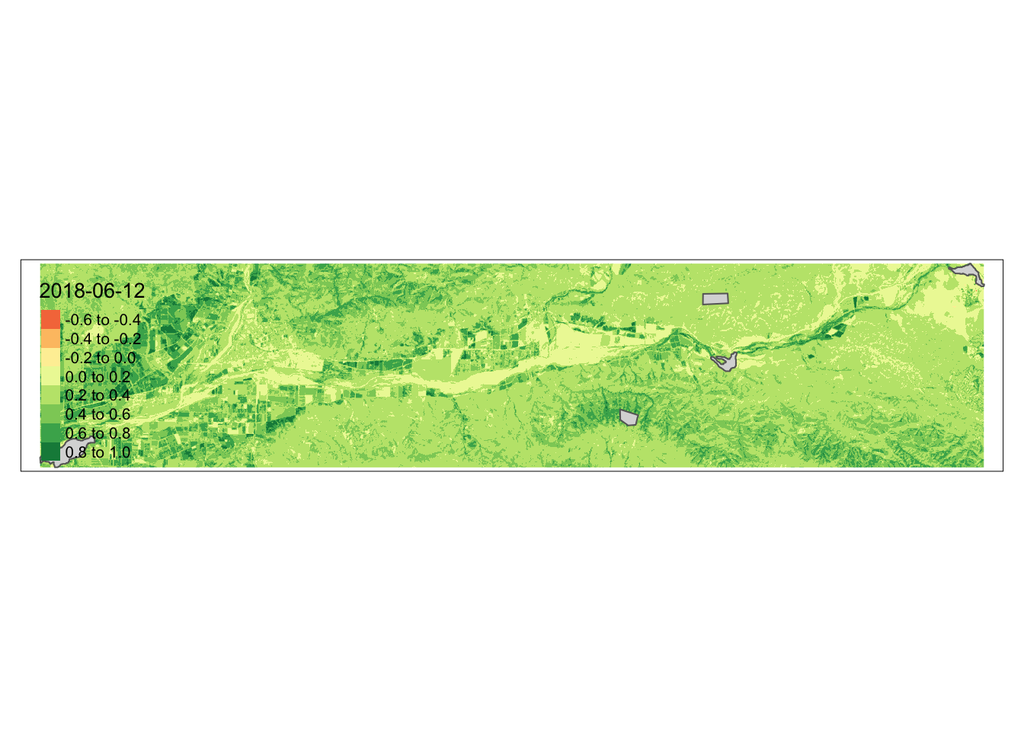

```r
# load sites data
sites <- st_read(here::here("data/study_sites.shp"))

# plot study sites on a single NDVI layer
tm_shape(all_ndvi[[1]]) +
  tm_raster() +
  tm_shape(sites) +
  tm_polygons()
```

```r
# extract the mean ndvi of cells in each study sites
sites_ndvi <- terra::extract(all_ndvi, sites, fun = "mean")

# bind to original sites data to include attributes
sites_annotated <- cbind(sites, sites_ndvi)
sites_annotated
```

Lastly, we visualized the NDVI results for each site.

```r
sites_clean <- sites_annotated %>%
  st_drop_geometry() %>%
  select(-ID) %>%
  pivot_longer(!study_site, names_to = "name", values_to = "ndvi") %>%
  mutate(date = lubridate::as_date(gsub("X", "", name))) %>%
  select(-name) %>%
  as.data.frame()
```

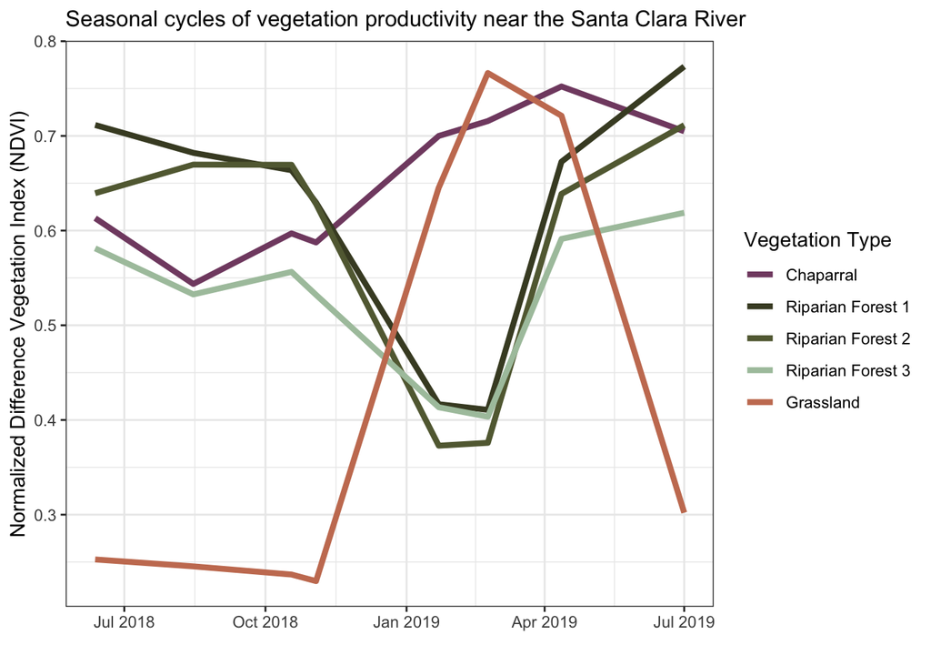

**Figure 1: Seasonal cycles of vegetation productivity near the Santa Clara River.** Monthly NDVI values are shown between June 2018 and July 2019. Colors represent dominant vegetation type of five study sites.

```r
ndvi_plot <- ggplot() +
  geom_line(data = sites_clean, aes(x = date, y = ndvi, group = study_site, col = study_site), linewidth = 1.5) +
  scale_color_manual(values = c("#824C71", "#474A2C", "#636940", "#ABC4AB", "#C97D60"), labels = c("Chaparral", "Riparian Forest 1", "Riparian Forest 2", "Riparian Forest 3", "Grassland")) +
  labs(
    x = "", y = "Normalized Difference Vegetation Index (NDVI)",
    col = "Vegetation Type",
    title = "Seasonal cycles of vegetation productivity near the Santa Clara River"
  ) +
  theme_bw() +
  theme(plot.title = element_text(size = 12, hjust = 0))

ndvi_plot
```

```r
# save figure
ggsave("figures/seasonal_ndvi.png", ndvi_plot, width = 8, height = 6, units = "in")
```

We found that chaparral, riparian forest, and grassland vegetation communities all employ different phenological strategies (Figure 1).

Chaparral shrublands exhibited a relatively high and stable NDVI throughout the year, which indicates they utilize an evergreen strategy where they attain their leaves year-round; NDVI was slightly higher in the winter when water availability is higher, but the difference with the summer season is not drastic.

Riparian forests exhibited distinctive seasonal dynamics in NDVI, with a higher NDVI in the summer relative to the winter. This indicates a winter deciduous phenology strategy where the vegetation (e.g., cottonwood and willow trees) lose their leaves in the winter and grow new leaves in the spring in response to changes in temperature, water availability, and light conditions.

Grasslands exhibited distinctive seasonal dynamics in NDVI as well, with a lower NDVI in the summer and a higher NDVI in the winter. This indicates a drought deciduous phenology strategy, where the vegetation loses its leaves in the summer when moisture availability is low.